# Credit Card Users Churn Prediction

- Compare the model performance of tuned models - Choose the best model

```python
models_tuned = ['AdaBoost_tuned','Gradient Boost_tuned','XGBoost_tuned']

train_perf_tuned= pd.concat([
perf_ada_tuned_train_set,
perf_gboost_tuned_train_set,
perf_xgboost_tuned_train_set],axis=0)

train_perf_tuned.set_index([pd.Index(models_tuned)], inplace=True)


val_perf_tuned = pd.concat([
perf_ada_tuned_val_set,
perf_gboost_tuned_val_set,
perf_xgboost_tuned_val_set],axis=0)

val_perf_tuned.set_index([pd.Index(models_tuned)], inplace=True)

print("Training performance VS Validation performance comparison with the best 3 models to tune:")

tuned_models = pd.concat([train_perf_tuned,val_perf_tuned],axis=1 )
tuned_models
```

```
Training performance VS Validation performance comparison with the best 3 models to tune:
```

|  | Accuracy | Recall | Precision | F1 | Accuracy | Recall | Precision | F1 |
| --- | --- | --- | --- | --- | --- | --- | --- | --- |
| AdaBoost_tuned | 0.998361 | 0.999180 | 0.997545 | 0.998362 | 0.945893 | 0.948403 | 0.768924 | 0.849285 |
| Gradient Boost_tuned | 0.983197 | 0.986885 | 0.979658 | 0.983258 | 0.952212 | 0.943489 | 0.796680 | 0.863892 |
| XGBoost_tuned | 0.995902 | 1.000000 | 0.991870 | 0.995918 | 0.938389 | 0.968059 | 0.733706 | 0.834746 |

**Conclusion:**

- The Tuned XGBoost model perfromance is showing the best recall on the validation set. Yet, the GBoost model is showing the least overfitting. Hence, based on the performance, the model moving on to the production is the XGBoost_tuned model.

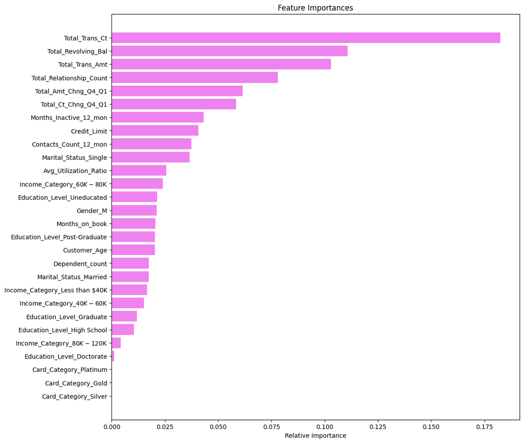

```python
feature_names = X_train.columns
importances = xgboost_tuned.feature_importances_
indices = np.argsort(importances)

plt.figure(figsize=(12,12))
plt.title('Feature Importances')
plt.barh(range(len(indices)), importances[indices], color='violet', align='center')
plt.yticks(range(len(indices)), [feature_names[i] for i in indices])
plt.xlabel('Relative Importance')
plt.show()
```

**Productionize the model**

Now, as we have a final model we will use pipelines to put the model into production. We will start by creating a column transformer pipeline to handle any missing values in numercial and categorical variables, in addition to performing one hot encoding on the categorical variables. Last step is creating the final pipeline with the model and fitting it to the train data and finally observing the performance on the test set.

**1. Column Transformer**

```python
#we will import the make_column_selector to apply the imputers on each the numerical and categorical variables
from sklearn.compose import make_column_selector as selector
```

```python
#creating the numerical transformer using the sipmle imputer with strategy "median" and applying a standard scaler
numerical_transformer = make_pipeline(SimpleImputer(strategy="median"),
                                     StandardScaler())

#creating the categorical transformer using the sipmle imputer with strategy "most_frequent"
categorical_transformer= make_pipeline(SimpleImputer(strategy="most_frequent"),
                                      OneHotEncoder(handle_unknown="ignore"))

#creating the column transformer
preprocessor = ColumnTransformer(
    transformers=[
        ('num', numerical_transformer, selector(dtype_exclude="category")),
        ('cat', categorical_transformer, selector(dtype_include="category"))
    ],
    remainder="passthrough",
)
```

**2. Separating target variable and other variables**

```python
X = df.drop(columns="Attrition_Flag",axis=1)
y= df["Attrition_Flag"].replace(['Existing Customer','Attrited Customer'],[0,1])

#replacing the junk value with NaN
X['Income_Category'] = X['Income_Category'].replace('abc', np.NaN)

#converting the objects into category
for i in categorical:
    X[i] = X[i] .astype('category')
```

**3. Splitting the data to train and test**

As we already know the best model we need to process with, so we don't need to divide data into 3 sets - train, validation and test

```python
#splitting the data into train and test via 70:30 ratio.
from sklearn.model_selection import train_test_split

# Splitting the data into train and test sets with a 70:30 ratio
X_train_final, X_test_final, y_train_final, y_test_final = train_test_split(X, y, test_size=0.3, random_state=1, stratify=y)

# Print the shape of the train and test sets
print(X_train_final.shape, X_test_final.shape)
```

```
(7088, 18) (3039, 18)
```

**4. Creating the final pipeline with the model**

```python
model = make_pipeline(preprocessor,XGBClassifier(subsample=0.7, scale_pos_weight = 4,
                                             n_estimators= 40, learning_rat= 0.06,
                                             colsample_bytree= 0.9, colsample_bylevel= 0.7,
                                            random_state=1, eval_metric='logloss'))
```

```python
#fitting the model on the training set
model.fit(X_train_final, y_train_final)
```

```
Pipeline(steps=[('columntransformer',
                 ColumnTransformer(remainder='passthrough',
                                   transformers=[('num',
                                                  Pipeline(steps=[('simpleimputer',
                                                                   SimpleImputer(strategy='median')),
                                                                  ('standardscaler',
                                                                   StandardScaler())]),
                                                  <sklearn.compose._column_transformer.make_column_selector object at 0x7c57792af460>),
                                                 ('cat',
                                                  Pipeline(steps=[('simpleimputer',
                                                                   SimpleImputer(strategy=...
                               feature_types=None, gamma=None, grow_policy=None,
                               importance_type=None,
                               interaction_constraints=None, learning_rat=0.06,
                               learning_rate=None, max_bin=None,
                               max_cat_threshold=None, max_cat_to_onehot=None,
                               max_delta_step=None, max_depth=None,
                               max_leaves=None, min_child_weight=None,
                               missing=nan, monotone_constraints=None,
                               multi_strategy=None, n_estimators=40,
                               n_jobs=None, num_parallel_tree=None, ...))])
```

```
Model Performance on training set
   Accuracy    Recall  Precision        F1
0  0.994074  0.999122   0.965225  0.981881
```

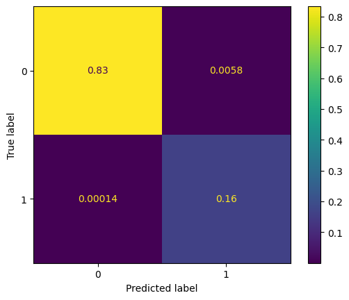

```python
#model performance evaluation on training set
from sklearn.metrics import ConfusionMatrixDisplay, confusion_matrix
import matplotlib.pyplot as plt

# Model Performance Evaluation on Training Set for the Final Model
final_train_set = model_performance(model, X_train_final, y_train_final)
print(f'''Model Performance on training set
{final_train_set}''')

# Step 1: Generate the confusion matrix for the training set
cm = confusion_matrix(y_train_final, model.predict(X_train_final), normalize='all')

# Step 2: Display the confusion matrix using ConfusionMatrixDisplay
disp = ConfusionMatrixDisplay(confusion_matrix=cm)
disp.plot()

# Show the plot
plt.show()
```

```
Model Performance on test set
   Accuracy    Recall  Precision        F1
0  0.971043  0.940574     0.8861  0.912525
```

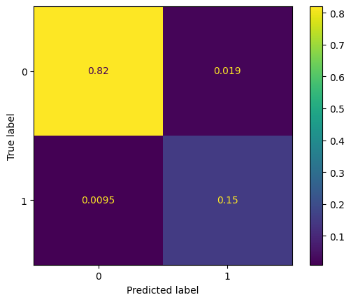

```python
#model performance evaluation on test set
from sklearn.metrics import ConfusionMatrixDisplay, confusion_matrix
import matplotlib.pyplot as plt

# Model Performance Evaluation on Test Set for the Final Model
final_test_set = model_performance(model, X_test_final, y_test_final)
print(f'''Model Performance on test set
{final_test_set}''')

# Step 1: Generate the confusion matrix for the test set
cm = confusion_matrix(y_test_final, model.predict(X_test_final), normalize='all')

# Step 2: Display the confusion matrix using ConfusionMatrixDisplay
disp = ConfusionMatrixDisplay(confusion_matrix=cm)
disp.plot()

# Show the plot
plt.show()
```

**Actionable Insights & Recommendations**

**Business insights:**

The Univarate Analysis shows the below common characteristics among customers:

- 16.1% of the customers as Attrited and 83.9% as existing
- 53% of the client base are females
- 93% carry the Blue card
- 35% belong to the Income_category less than USD 40K
- 46% of customers are married

The Bivariate Analysis showed:

- The Credit_Limit and Avg_Open_To_Buy variables are very strongy correlated
- The Total_Trans_Amt and Total_Trans_Ct variables are strongly correlated
- The Strong Predictors and their Relation ship between variables and target variable are:
1. Attrited customers have less Total_Revolving_Bal,Total_Trans_Ct, Total_Trans_Amt,Total_Ct_Chng_Q4_Q1 and Total_Relationship_Count than Existing customers
2. Card_Category shows The highest ratio of Attrited customers as Platinum card holders.30% are graduates

**Classification model sum up:**

**Recommendation:**

- The top 5 features deriving the the customer to Churn are stated in the table below. Hence, it is recommended to follow up closely on how these features vary with every customer in order to approach the high-risk customers on the right time to understand on the dissatisfaction reasons and have a strategy in place to attain them such as: pitching an attractive promotional offer.

[output not shown]

- The model is also giving a strong preditcion on the existing customers, this can be utilized to explore closely the existing customers and the services they are satisfied with and enhancing them as a measure of strengthening the relationship and avoiding less to chrun in the future.